# Datathon Submission Template

[Retina AI](https://retina.ai)

24 September, 2020

## Retina AI R Datathon - Submission Template

*Team Name*: Zoom University  
*Team Members*: Kyle Fang, Jiahao Huang, William Foote  
*Team Members Email*: kylefang19@g.ucla.edu, jiahao303@g.ucla.edu, williamfoote@g.ucla.edu  
*Designated Slides*: Slides 12-13

*Directions*: Write your text and codes for Task 1, 2 and 3 in the provided space below.

Task 1 insights to the visualization can be written as plain text in the field provided below. You can also add new bullet points to each slide’s insights section.

For Task 2 and 3, provide your codes in the code chunks below. If your team needs additional code chunks to run your code, you can add new code chunks.

## Task 1 (Required)

*Slide Number*: 12

*Key Insights min 2 / max 4*:  
1. The tailedness of a distribution quanitifed by kurtosis. A heavy tail in the raw number of customers indicates a very highly peaked distribution or many outliers. The implications of this are dependent on the skewedness.

A heavy tail with left-skewed data translates to a lot of high-paying customers, which is very good for the company. However, a heavy tail matched with right-skewed data translates to reliance on a few high-paying customers.

On the other hand a low tail indicates a flatter distribution and less outliers. Generally there is less risk as the customer based is diversified and not heavily relying on a few high-paying customers.

2. The skewedness of the plot measured by skewedness. A left skew means there are a lot of high-paying customers, which is great for the business. No skew means the company is reliant on the average customer, and the average customer is robust. Right skew means there are only a few high-paying customers, which is not good because the company is reliant on these few high-paying customers.

*Slide Number*: 13

*Key Insights min 2 / max 4*:  
1. Whether the mean is greater than the median.

If the mean is greater than the median, the LTR distribution is right-skewed. The business is reliant on a small amount of high-spending customers.

If the median is greater than the mean, the LTR distribution is left-skewed. The business has a big number of high-spending customers.

2. Whether the relationship between the median and mean change over time. This has different implications depending on whether or not the mean is greater than median.
3. The existence of “pesky trends”. The periods of time (6 months) where the trend of the difference between the median and mean of the LTR is unusual compared to the overall trend. This has different implications depending on whether or not the mean is greater than the median. The pesky trends are helpful in determining if the trends in the current times are consistent with the overall trend.
4. The exact times of those pesky trends. Those times should be further investigated as it could indicate times of unusual success or failure for the business, and one might be interested to see what other factors lead to these abnormalities.

## Task 2 (Required)

*Slide Number*: 12

[output not shown]

*Slide Number*: 13

[output not shown]

[output not shown]

```
## [1] "The recent trend of the LTR matches the overall trend of the data."
```

## Task 3 (Bonus/Optional)

*Key Insights min 2 / max 4*: - Kurtosis and Skewness visualization

*How to read this chart*: The boxes represent how close or far the point is to being in the ideal kurtosis and skewness levels. This graph visualizes insight 1 and 2 in slide and allows the user to tell how far and in what direction is he away from normal distribution.

Because there is no standard cutoff for kurtosis or skewness in determining whether a distribution is truly classified as normal, this plot can help users get a sense of how far there distribution is from normal distribution.

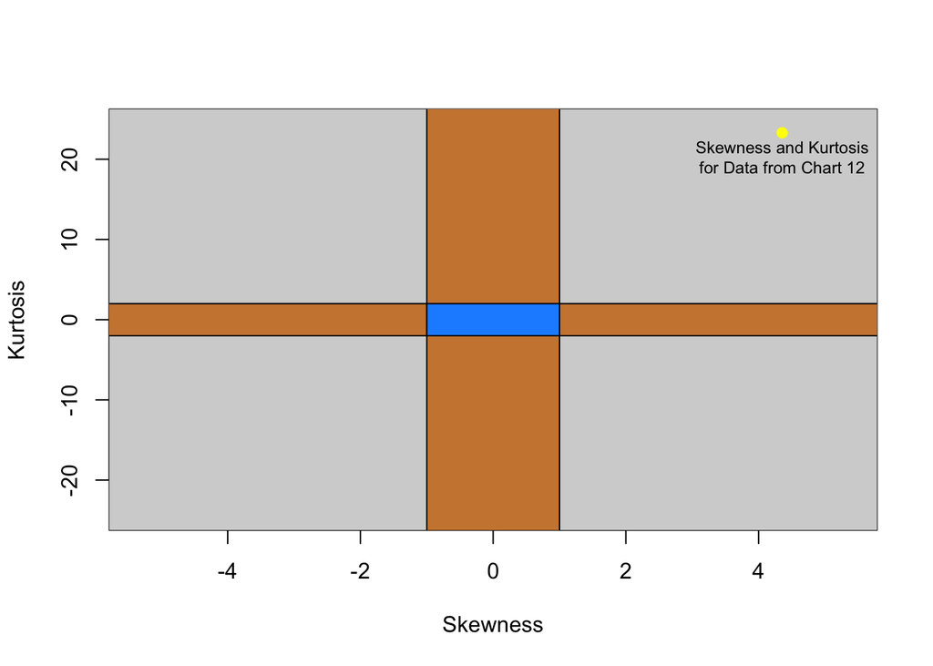

*Key Insights min 2 / max 4*: - Boxplot of rolling slope estimates for the difference of the means and medians. *How to read this chart*: - The boxplot shows potential instances where the slope estimate for a given time period subset is outlyingly different than the other slope estimates. It shows visualizes how extreme the outlying are.

When the mean is greater than the median, the following statements are true.

- The outliers on the right indicate time periods where the businesses are becoming unusually more dependent on a few, high-spending customers.
- The outliers on the left indicate time periods where businesses are unusually successful in becoming less dependent on a few, high-spending customers.

When median is greater than the mean, the opposite is true.

- The outliers on the right indicate time periods where businesses are unusually successful in becoming less dependent on a few, low-spending customers.
- The outliers on the left indicate time periods where the businesses are becoming unusually more dependent on a few, low-spending customers.

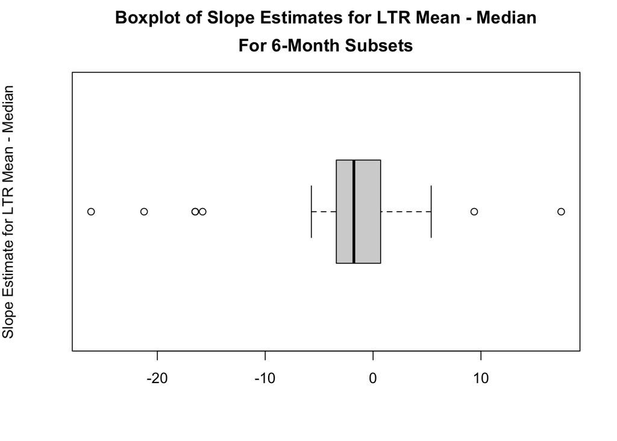

If the trend at the end (near current months) is different from the overall trend, there is cause for worry. It should be investigated further as the business’s risk profile may have changed recently and could be changing changing currently.

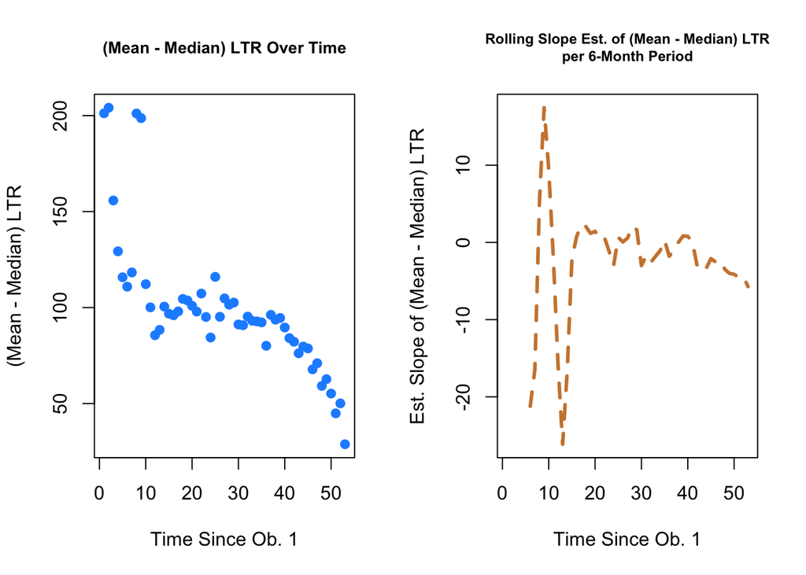